# PPS

## Processi di Punto Spaziale

### SPATIAL POINT PROCESSES

**General aspects**

Definition: a SPP $N = {s_1, s_2,...s_n : s_i \in W}$ is a finite or countable collection of random locations (events) in a region $W \subseteq R^2$

Where W is called the process window and the point pattern, ${s_1, s_2,...,s_n}$ constitutes a set of realizations of random points (not predetermined) of W

From this definition we deduce that there are two elements of randomness:

- Number of events
- Location of events

**Types of SPP based on the process support**

- Finite SPP
- Infinite SPP

**Types of SPP based on the observation mode of the point pattern**

- SPP sampled
- SPP mapped

### Intensity of a SPP

Notation N(B): number of events in the set $B$ of $R^2$ (counting measure), planar SPP locally finite and $\sigma-additive$ counting measure
$$|B|:area \space of \space B$$

The intensity measure of a SPP is the expected value of $N(B)$:
$$E[N(B)]= \mu(B)$$
"parameter" of the process dependent on the considered set B.

Under regularity conditions there exists a deterministic function, $\lambda(s)$, such that:

$$\mu(B)=\int_B{\lambda(s) ds}$$
$\lambda(s)$: intensity function

### Objectives of the analysis of a spatial PP

1. Assessments on the presence of spatial patterns (clusters/regularity)
2. Estimation of the intensity with which events occur in space

# Poisson processes

The simplest stochastic model for a planar point model is the homogeneous Poisson process. A Poisson process, named after the French mathematician Siméon-Denis Poisson, is a stochastic process that simulates the occurrence of events that are independent of each other and that happen continuously in time and/or space. The Poisson process is one of the most widely used counting processes. It is usually used in scenarios where we are counting occurrences of certain events that seem to happen at a certain rate, but completely at random (without a certain structure).

Examples of use of this process:

- the number of traffic accidents in a site or area;
- the position of users in a wireless network;
- requests for individual documents on a web server;
- the outbreak of wars;
- phone calls arriving at a switchboard;
- manufacturing defects.

## Homogeneous Poisson Processes (HPP: Homogeneous Poisson Process)

The idea of this model is that events (point of interest) occur completely independently of each other. This lack of interaction between points is called complete spatial randomness.

**Formal definition**

Let $N(B)$ be the number of events in the set $B$ of $R^2$ (i.e., the counting measure) and $|B|$ the area of $B$ then for every $B$ (subregion) bounded set of $W$ included in $R^2$ we have that $N(B) \sim P(\eta)$ where $\eta = \lambda \space |B|$ and that for any $B_1, ..., B_k$ such that $B_i \cap B_j = \emptyset$ with $i$ different from $j$ we have that $N(B_1), ... , N(B_k)$ are independent r.v.

In less formal terms, a point process is defined as homogeneous Poisson if for every subregion $B$ that I take in the process window $W$ the number of events present in the subregion is distributed as a Poisson distribution that depends on a certain parameter $\lambda$ (called process intensity) multiplied by the size of the region taken in analysis $|B|$. Furthermore, it must also be true that if we take two subregions of $W$ $B_1$ and $B_2$ disjoint from each other, the number of events present in the two regions must be independent.

For many years, almost all methods available for the statistical analysis of planar point patterns were based on the assumption that the points in question constitute the realization of a homogeneous planar Poisson process. Although there is now a wide variety of alternative point process models, the homogeneous Poisson process still provides a basic reference model against which to compare other models.

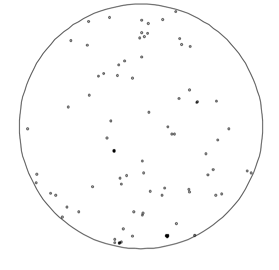

## Processi di Poison non Omogenei (IHPP - Inhomogeneous Poisson Process)

In casi reali come ad esempio per i difetti di fabbricazione alcune regioni sono più “esposte” al fenomeno di altre presentando una certa “sistematicità” e quindi l’intensità del processo varia nello spazio.
$$\lambda \rightarrow \lambda(s)$$

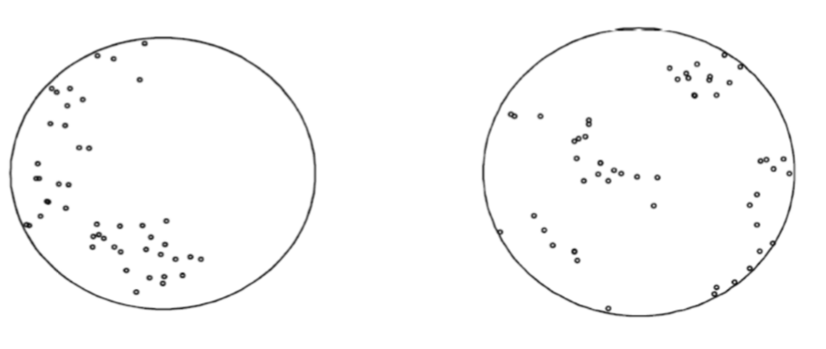